# Survival Analysis of Dealers and DRMs

2023-10-12

# Load Libraries and Data

```r
library(tidyverse)
library(ggplot2)
library(survival)
library(survminer)
library(knitr)
```

```r
surv_data <- read.csv("Survival Data.csv")
```

# EDA

Let’s first take a look at the data to see which columns are needed and if they are the correct class.

```r
summary(surv_data)
```

```
##        X           source_id             count                time
##  Min.   :   1.0   Length:1266        Min.   :     1.00   Min.   : 1.00
##  1st Qu.: 317.2   Class :character   1st Qu.:    99.25   1st Qu.:13.00
##  Median : 633.5   Mode  :character   Median :   335.00   Median :27.00
##  Mean   : 633.5                      Mean   :  1415.94   Mean   :25.57
##  3rd Qu.: 949.8                      3rd Qu.:   984.75   3rd Qu.:40.00
##  Max.   :1266.0                      Max.   :178058.00   Max.   :40.00
##      name            source_type     status        territory
##  Length:1266        Min.   :6    Min.   :0.0000   Length:1266
##  Class :character   1st Qu.:6    1st Qu.:0.0000   Class :character
##  Mode  :character   Median :6    Median :0.0000   Mode  :character
##                     Mean   :6    Mean   :0.2457
##                     3rd Qu.:6    3rd Qu.:0.0000
##                     Max.   :6    Max.   :1.0000
##       AE                DRM                RSM                 age
##  Length:1266        Length:1266        Length:1266        Min.   :0.0274
##  Class :character   Class :character   Class :character   1st Qu.:0.4575
##  Mode  :character   Mode  :character   Mode  :character   Median :0.8959
##                                                           Mean   :1.1309
##                                                           3rd Qu.:1.2199
##                                                           Max.   :6.4384
```

We can remove the X column, and source_type. We will factor status, name, and see what we want to do with AE, RSM, DRM.

source_id is the id of each dealer, we can ignore this for the time being.  
Time is the total weeks each dealer survived in the experiment.  
Count is how many times each dealer looked up a unique vehicle.  
Age is the total years that the dealer has been around since they joined the product. Since we are trying to run a survival analysis, we need to mainly focus on the dealers who did not survive the trial. However, it is crucial for us to have some censored data. It can vary widely for how much censored data we need. In this case we will match the censored data too the uncensored data.

```r
surv_data <- surv_data |>
  mutate(name = as.factor(name)) |>
  select(-c(X, source_type))
```

Let’s separate our cancels from our actives to be able to change the amount of active we are using in our analysis.

```r
surv_data1 <- surv_data |>
  filter(status == 1)
```

```r
set.seed(500)
filtered <- surv_data |>
  filter(status == 0) |>
  sample_n(300)
```

Let’s combine the cancels and actives to make a ‘working’ data frame.

```r
surv_data1.2 <- rbind(surv_data1, filtered)
```

Since we have some missing data in our drm column, we will assign this to be no drm assigned.

```r
surv_data1.2 <- surv_data1.2 |>
  mutate(DRM = ifelse(is.na(DRM) | DRM == "", "No DRM", DRM))
```

```r
summary(surv_data1.2)
```

```
##   source_id             count              time                   name
##  Length:611         Min.   :    1.0   Min.   : 1.00   Access Base   :  1
##  Class :character   1st Qu.:   64.5   1st Qu.:10.00   Appraiser Plus:  0
##  Mode  :character   Median :  234.0   Median :21.00   Connected     :595
##                     Mean   :  736.5   Mean   :22.15   Core          : 15
##                     3rd Qu.:  749.0   3rd Qu.:37.00
##                     Max.   :25956.0   Max.   :40.00
##      status       territory              AE                DRM
##  Min.   :0.000   Length:611         Length:611         Length:611
##  1st Qu.:0.000   Class :character   Class :character   Class :character
##  Median :1.000   Mode  :character   Mode  :character   Mode  :character
##  Mean   :0.509
##  3rd Qu.:1.000
##  Max.   :1.000
##      RSM                 age
##  Length:611         Min.   :0.0274
##  Class :character   1st Qu.:0.5438
##  Mode  :character   Median :0.9205
##                     Mean   :1.1344
##                     3rd Qu.:1.2110
##                     Max.   :6.2137
```

# Survival Analysis

Let’s set our Surv model. This will be time and status against the intercept.

```r
dealer.time <- surv_data1.2$time
dealer.status <- surv_data1.2$status

dealer.surv <- Surv(dealer.time, dealer.status) # our survival function

dealer.survfit <- survfit(dealer.surv ~ 1)
```

```r
dealer.survfit
```

```
## Call: survfit(formula = dealer.surv ~ 1)
##
##        n events median 0.95LCL 0.95UCL
## [1,] 611    311     28      26      33
```

For sake of big-data, lets convert the weeks to days. This will give us a larger and more incremented time value.

```r
surv_data1.2$time <- surv_data1.2$time * 7 # convert weeks to days
```

we can run this again to see the difference.

```r
dealer.time <- surv_data1.2$time
dealer.status <- surv_data1.2$status

dealer.surv <- Surv(dealer.time, dealer.status) # our survival function

dealer.survfit <- survfit(dealer.surv ~ 1)
```

```r
dealer.survfit
```

```
## Call: survfit(formula = dealer.surv ~ 1)
##
##        n events median 0.95LCL 0.95UCL
## [1,] 611    311    196     182     231
```

Out of 611 dealers, 311 events occurred (dealers cancelled). 196 was the median amount of days a dealer survived; on average half the dealers survived 196 days. There is a 95% confidence interval of (182, 231) meaning that with 95% confidence we can say that half the dealers survived a minimum of 182 days and a maximum of 231 days. For our specific sample, 196 days is where half our dealers dropped off.

We can keep adding more data to get some more accurate results. I have played around with this a lot and done all types of sampling and I’ve noticed that no matter the ratio of active to non-active dealers, we get pretty much the same results. I will add on much more data but keep in mind that there is not perfect rule of thumb that will give accurate results all data is different.

```r
# Grab 600 actives
set.seed(500)
filtered <- surv_data |>
  filter(status == 0) |>
  sample_n(600)

# Append to end of frame
surv_data2 <- rbind(surv_data1, filtered)

# Fix missing data
surv_data2 <- surv_data2 |>
  mutate(DRM = ifelse(is.na(DRM) | DRM == "", "No DRM", DRM))

# Convert weeks to days
surv_data2$time <- surv_data2$time * 7

# Set survival function
dealer.time <- surv_data2$time
dealer.status <- surv_data2$status

dealer.surv <- Surv(dealer.time, dealer.status) # our survival function

dealer.survfit <- survfit(dealer.surv ~ 1)

dealer.survfit
```

```
## Call: survfit(formula = dealer.surv ~ 1)
##
##        n events median 0.95LCL 0.95UCL
## [1,] 911    311     NA      NA      NA
```

## Kaplan-Meier Curve

Plotting a Kaplan-Meier Curve will give us insight to how the dealers react throughout the duration of the experiment. This first curve will be the survival function without the effect of any other covariates. Basically, it just gives us an insight into how long dealers typically last before cancelling and what their probability of staying subscribed to the product is at each time stamp.

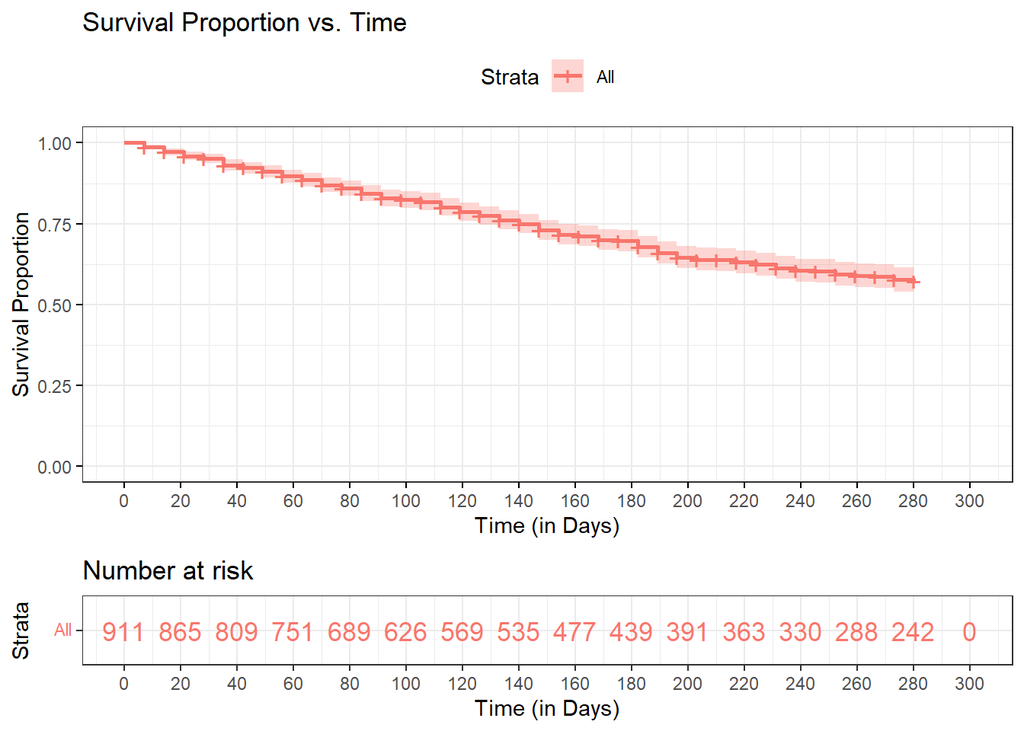

```r
ggsurvplot(survfit(Surv(time, status) ~ 1, data = surv_data2),
           break.x = 20,
           xlab = "Time (in Days)",
           ylab = "Survival Proportion",
           title = "Survival Proportion vs. Time",
           legen.labs = c("All Covariates"),
           risk.table = TRUE,
           risk.table.col = "strata",
           surv.median.line = "h",
           ggtheme = theme_bw())
```

**Figure 1: Kaplan-Meier curve with no covariates**

By day 280, there are 242 people still in the experiment or under observation. This means that 669 dealers were either censored or cancelled. A censoring can be due to a dealer coming in late and only being active for a few days or they were active the entirety of the experiment and are still active today. This means that 242 dealers were active the total 40 weeks of the experiment.

Now, let’s incorporate the DRM’s into the survival function. We will get an estimate of which dealers are performing the best in our sample.

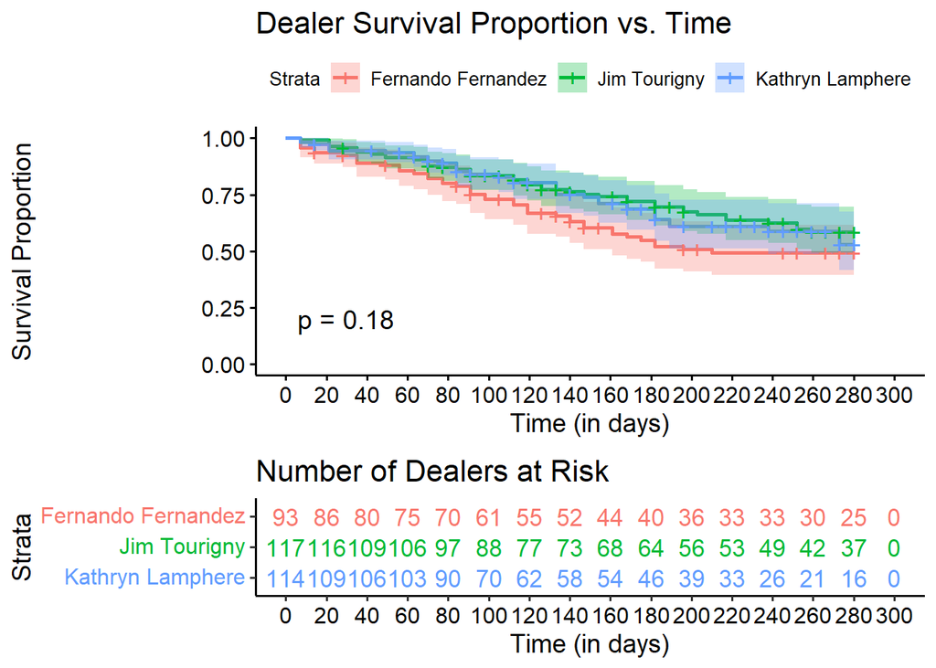

```r
drm_group1 <- surv_data2[surv_data2$DRM %in% c("Fernando Fernandez",
                                               "Jim Tourigny",
                                               "Kathryn Lamphere"),]
drm_group2 <- surv_data2[surv_data2$DRM %in% c("Don Thompson",
                                               "Sergio Suun",
                                               "Robert Krajecki"),]
drm_group3 <- surv_data2[surv_data2$DRM %in% c("Taki Caranicolas",
                                               "Will Smithies",
                                               "No DRM"),]

ggsurvplot(survfit(Surv(time, status) ~ as.factor(DRM), data = drm_group1),
           break.x.by = 20,
           conf.int = TRUE,
           pval = TRUE,
           risk.table = T,
           risk.table.col = "strata",
           risk.table.height = 0.33,
           risk.table.title = "Number of Dealers at Risk",
           legend.labs = c("Fernando Fernandez",
                           "Jim Tourigny",
                           "Kathryn Lamphere"),
           xlab = "Time (in days)",
           ylab = "Survival Proportion",
           title = "Dealer Survival Proportion vs. Time")
```

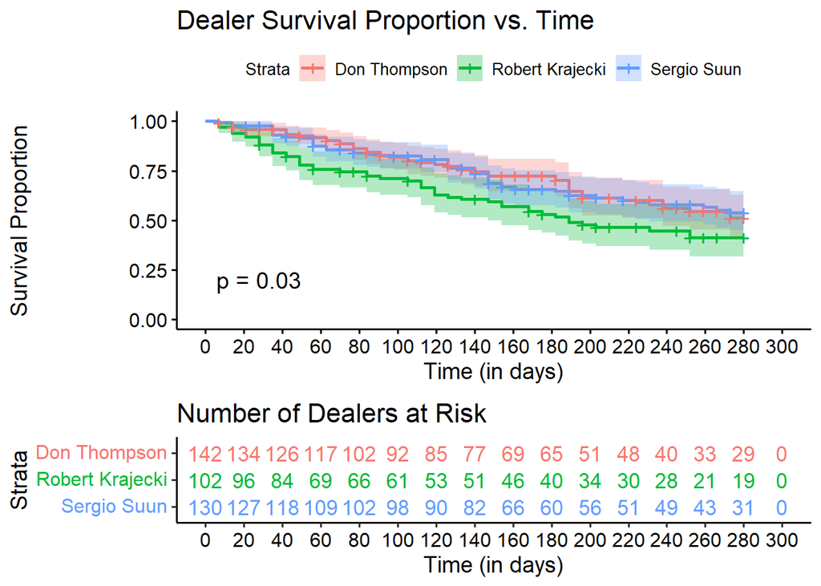

```r
ggsurvplot(survfit(Surv(time, status) ~ as.factor(DRM), data = drm_group2),
           break.x.by = 20,
           conf.int = TRUE,
           pval = TRUE,
           risk.table = T,
           risk.table.col = "strata",
           risk.table.height = 0.33,
           risk.table.title = "Number of Dealers at Risk",
           legend.labs = c("Don Thompson",
                           "Robert Krajecki",
                           "Sergio Suun"),
           xlab = "Time (in days)",
           ylab = "Survival Proportion",
           title = "Dealer Survival Proportion vs. Time")
```

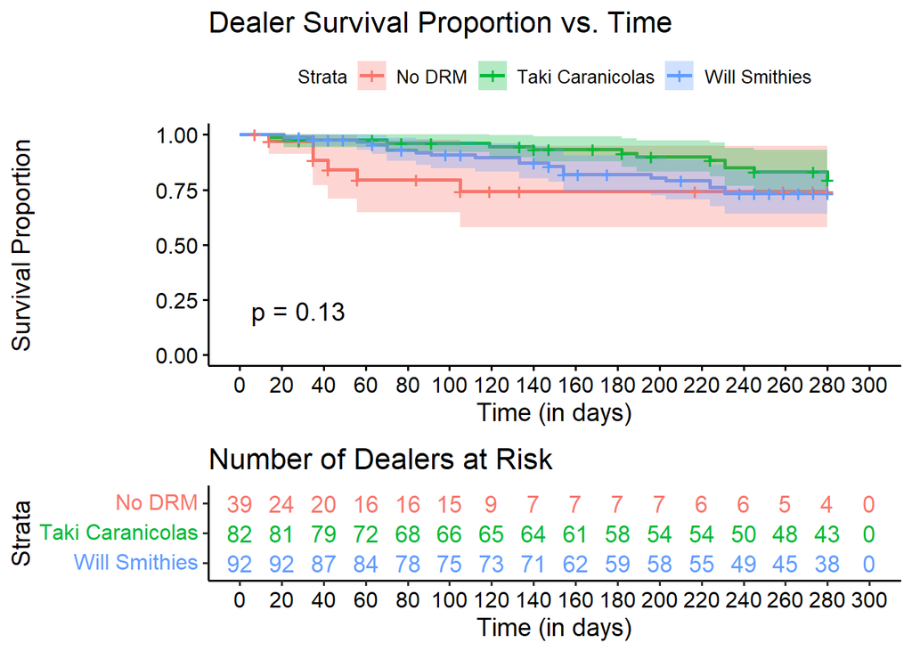

```r
ggsurvplot(survfit(Surv(time, status) ~ as.factor(DRM), data = drm_group3),
           break.x.by = 20,
           conf.int = TRUE,
           pval = TRUE,
           risk.table = T,
           risk.table.col = "strata",
           risk.table.height = 0.33,
           risk.table.title = "Number of Dealers at Risk",
           legend.labs = c("No DRM",
                           "Taki Caranicolas",
                           "Will Smithies"),
           xlab = "Time (in days)",
           ylab = "Survival Proportion",
           title = "Dealer Survival Proportion vs. Time")
```

**Figure 2-4: Kaplan-Meier curve split by DRM.**

From the figures above we can see how the DRMs perform across the time period. It is noteable that “No DRM” has the least amount of dealers to start out with and the worst retention rate. Taki Caranicolas has almost double that but his retention rate is much higher. Will Smithies has the third lowest but the second best retention rate. Fernando Fernandez has 1 more than Will Smithies but by the end he 13 less dealers who stayed the entire experiment. Robert Krajecki and Kathryn Lamphere have over 100 dealers to start out with but end up with sub 20 by day 280. This gives us some good first insight at DRM standings, but we will need to see how many dealers were censored vs actually cancelled to get a true idea of how each DRm performed.

*I say “retention rate” but this is technically inaccurate. The time period is 280 days (40 weeks) and the number at 280 is how many dealers each DRM had the full 40 weeks. Some dealers may have came in late, thus, don’t show in the later days of the experiment. Keep in mind that this is a sample of active dealers along with a complete set of cancelled dealers; about a 2:1 ratio.*

Since those numbers at the end there (day 280) may be deceptive to a beginners feeble eye, we can list how many actives and cancels each dealer had. This will give us a better idea of who is experiencing censoring and who is experiencing dealer cancellations.

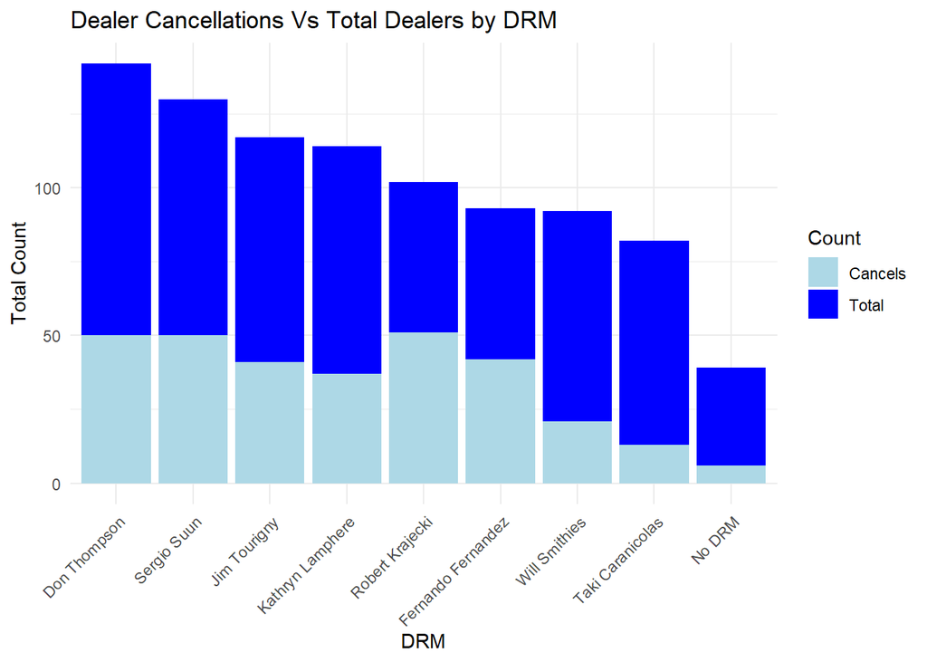

```r
# Wrangle df
cancelled_df <- surv_data2 |>
  select(DRM, status) |>
  group_by(DRM) |>
  summarise(count = n(),
            cancel_count = sum(status == 1))

# Make Vis
cancelled_df |> ggplot(aes(x = reorder(DRM, -count))) +
  geom_bar(aes(y = count, fill = "Total"),
           stat = "identity",
           position = "stack") +
  geom_bar(aes(y = cancel_count, fill = "Cancels"),
           stat = "identity",
           position = "stack") +
  scale_fill_manual(values = c("Total" = "blue",
                               "Cancels" = "lightblue")) +
  labs(x = "DRM", y = "Total Count",
       title = "Dealer Cancellations Vs Total Dealers by DRM",
       fill = "Count") +
  theme_minimal() +
  theme(legend.position = "right",
        axis.text.x = element_text(angle = 45, hjust = 1))
```

**Figure 5: Stacked bar chart of dealer cancellations and total dealers for each DRM**

This gives us a much better idea of how many cancellations/censors each DRM has. For example, before it seemed like Kathryn Lamphere was losing all of her dealers and only had 16 left. Now we can see that she really only lost about 37 of her dealers and the other 61 she supposedly “lost” were really censored because they came into the survey period late. AKA they are simply new dealers who havent been around the full 40 week (280 day) period. This also goes to show that Taki and Will are outstanding DRMs. It somewhat amazing that not having a DRM at all has still kept 4 dealers around.

## Cox PH Models

Lets look at some Cox Proportional Hazard models to see our hazard ratios. Since we are really just looking at our DRMs right now that will be our variable of interest.

```r
drm <- factor(surv_data2$DRM)
dealer.fit <- coxph(Surv(time, status) ~ drm, data = surv_data2)

summary(dealer.fit)
```

```
## Call:
## coxph(formula = Surv(time, status) ~ drm, data = surv_data2)
##
##   n= 911, number of events= 311
##
##                            coef exp(coef)  se(coef)      z Pr(>|z|)
## drmFernando Fernandez  0.235546  1.265600  0.209347  1.125 0.260528
## drmJim Tourigny       -0.150652  0.860147  0.210769 -0.715 0.474749
## drmKathryn Lamphere   -0.058141  0.943517  0.216918 -0.268 0.788674
## drmNo DRM             -0.191952  0.825346  0.432365 -0.444 0.657073
## drmRobert Krajecki     0.449624  1.567722  0.199039  2.259 0.023885 *
## drmSergio Suun        -0.004519  0.995491  0.200050 -0.023 0.981976
## drmTaki Caranicolas   -1.100783  0.332610  0.311648 -3.532 0.000412 ***
## drmWill Smithies      -0.701529  0.495827  0.260272 -2.695 0.007031 **
## ---
## Signif. codes:  0 '***' 0.001 '**' 0.01 '*' 0.05 '.' 0.1 ' ' 1
##
##                       exp(coef) exp(-coef) lower .95 upper .95
## drmFernando Fernandez    1.2656     0.7901    0.8397    1.9076
## drmJim Tourigny          0.8601     1.1626    0.5691    1.3001
## drmKathryn Lamphere      0.9435     1.0599    0.6167    1.4434
## drmNo DRM                0.8253     1.2116    0.3537    1.9260
## drmRobert Krajecki       1.5677     0.6379    1.0613    2.3158
## drmSergio Suun           0.9955     1.0045    0.6726    1.4734
## drmTaki Caranicolas      0.3326     3.0065    0.1806    0.6126
## drmWill Smithies         0.4958     2.0168    0.2977    0.8258
##
## Concordance= 0.61  (se = 0.016 )
## Likelihood ratio test= 46.16  on 8 df,   p=2e-07
## Wald test            = 39.76  on 8 df,   p=4e-06
## Score (logrank) test = 43.25  on 8 df,   p=8e-07
```

The concordance statistic (C-index) is 0.61, indicating the model’s ability to predict the order of event times. A concordance of 0.5 represents random prediction, so 0.61 suggests some predictive ability.

The likelihood ratio test, Wald test, and Score (logrank) test are all statistically significant (very low p-values), suggesting that the covariate `DRM` is associated with the time to the event. In other words, **there is evidence that the `DRM` variable has an impact on survival.**

The coefficients (coef) for the different levels of `DRM` are presented in the table. Each coefficient represents the log hazard ratio for that level compared to a reference level (Dom Thompson). Essentially, a positive number indicates they are likely to be more hazardous which means they will have more cancels. A negative number means the opposite.

The hazard ratio (exp(coef)) is the exponentiation of the coefficient, which gives an estimate of the relative risk of the event for each level compared to the reference level.

The standard error (se(coef)) shows us how much error is in this hazard ratio. This just means that coef could be plus or minus some standard error.

The z value is just used the same way as the p-value except the p-value doesn’t require math. **The rule of thumb here is that we don’t trust and information unless the p-value (Pr(>|z|)) is less that 0.05.**

The levels of `DRM` with asterisks, are suggesting they have a statistically significant impact on survival. For example, “DRMTaki Caranicolas” has a coefficient of -1.100783 and an associated hazard ratio of 0.332610. This means that individuals in the “Taki Caranicolas” group have a significantly lower risk of the event compared to the reference level. Essentially, where ever the coef, or exp(coef) are the lowest, these DRMs show a lower risk of dealer cancellation. However, we need to look at the p-values to determine if this lower risk of cancellation is statistically significant. We see that Taki, and Will have the lowest risk for cancellations.

*Note: This output displays results based on a reference DRM level. In this case, DRMDon Thompson is our reference. Let’s let each DRM be the reference 1 time.*

### Fernando Fernandez as reference

```r
drm <- relevel(factor(surv_data2$DRM), ref = "Fernando Fernandez")
summary(coxph(Surv(time, status) ~ drm, data = surv_data2))
```

```
## Call:
## coxph(formula = Surv(time, status) ~ drm, data = surv_data2)
##
##   n= 911, number of events= 311
##
##                        coef exp(coef) se(coef)      z Pr(>|z|)
## drmDon Thompson     -0.2355    0.7901   0.2093 -1.125 0.260528
## drmJim Tourigny     -0.3862    0.6796   0.2196 -1.759 0.078603 .
## drmKathryn Lamphere -0.2937    0.7455   0.2256 -1.302 0.192983
## drmNo DRM           -0.4275    0.6521   0.4368 -0.979 0.327683
## drmRobert Krajecki   0.2141    1.2387   0.2084  1.027 0.304381
## drmSergio Suun      -0.2401    0.7866   0.2093 -1.147 0.251433
## drmTaki Caranicolas -1.3363    0.2628   0.3176 -4.208 2.58e-05 ***
## drmWill Smithies    -0.9371    0.3918   0.2674 -3.504 0.000458 ***
## ---
## Signif. codes:  0 '***' 0.001 '**' 0.01 '*' 0.05 '.' 0.1 ' ' 1
##
##                     exp(coef) exp(-coef) lower .95 upper .95
## drmDon Thompson        0.7901     1.2656    0.5242    1.1910
## drmJim Tourigny        0.6796     1.4714    0.4420    1.0451
## drmKathryn Lamphere    0.7455     1.3414    0.4791    1.1601
## drmNo DRM              0.6521     1.5334    0.2771    1.5350
## drmRobert Krajecki     1.2387     0.8073    0.8233    1.8638
## drmSergio Suun         0.7866     1.2713    0.5219    1.1855
## drmTaki Caranicolas    0.2628     3.8051    0.1410    0.4898
## drmWill Smithies       0.3918     2.5525    0.2320    0.6617
##
## Concordance= 0.61  (se = 0.016 )
## Likelihood ratio test= 46.16  on 8 df,   p=2e-07
## Wald test            = 39.76  on 8 df,   p=4e-06
## Score (logrank) test = 43.25  on 8 df,   p=8e-07
```

Jim Tourigny shows potential to be a good DRM when compared to Fernando Fernandez. However, this is at a significance level of sub 0.1. This is more of a wow factor than any significant meaning, especially since his confidence interval contains 1. This shows that he is not a significant contributor in this summary. Taki and Will still show major significance in having less cancellations. Notice that when compared to Fernando Fernandez, Robert Krajeki shows no significance of anything. What does that say about Fernando?

Like we said above the tests at the very bottom are showing good signs and they will continue so I will not mention them again.

### Jim Tourigny as Reference

```r
drm <- relevel(factor(surv_data2$DRM), ref = "Jim Tourigny")
summary(coxph(Surv(time, status) ~ drm , data = surv_data2))
```

```
## Call:
## coxph(formula = Surv(time, status) ~ drm, data = surv_data2)
##
##   n= 911, number of events= 311
##
##                           coef exp(coef) se(coef)      z Pr(>|z|)
## drmDon Thompson        0.15065   1.16259  0.21077  0.715  0.47475
## drmFernando Fernandez  0.38620   1.47138  0.21957  1.759  0.07860 .
## drmKathryn Lamphere    0.09251   1.09693  0.22697  0.408  0.68357
## drmNo DRM             -0.04130   0.95954  0.43753 -0.094  0.92480
## drmRobert Krajecki     0.60028   1.82262  0.20988  2.860  0.00424 **
## drmSergio Suun         0.14613   1.15735  0.21072  0.693  0.48800
## drmTaki Caranicolas   -0.95013   0.38669  0.31842 -2.984  0.00285 **
## drmWill Smithies      -0.55088   0.57644  0.26841 -2.052  0.04014 *
## ---
## Signif. codes:  0 '***' 0.001 '**' 0.01 '*' 0.05 '.' 0.1 ' ' 1
##
##                       exp(coef) exp(-coef) lower .95 upper .95
## drmDon Thompson          1.1626     0.8601    0.7692    1.7573
## drmFernando Fernandez    1.4714     0.6796    0.9568    2.2627
## drmKathryn Lamphere      1.0969     0.9116    0.7030    1.7115
## drmNo DRM                0.9595     1.0422    0.4070    2.2620
## drmRobert Krajecki       1.8226     0.5487    1.2079    2.7501
## drmSergio Suun           1.1573     0.8640    0.7658    1.7492
## drmTaki Caranicolas      0.3867     2.5860    0.2072    0.7218
## drmWill Smithies         0.5764     1.7348    0.3406    0.9755
##
## Concordance= 0.61  (se = 0.016 )
## Likelihood ratio test= 46.16  on 8 df,   p=2e-07
## Wald test            = 39.76  on 8 df,   p=4e-06
## Score (logrank) test = 43.25  on 8 df,   p=8e-07
```

Jim Tourigny as the reference shows some mostly insignificant signs of Fernando Fernandez being a cause of more cancellations. Looking at Robert compared to Jim punctuates Roberts lacking skills. Roberts confidence interval does not contain 1 meaning he is a significant contributor to cancellations. Looking at his coef we see that it is positive meaning he has more cancellations.

### Kathryn Lamphere as Reference

```r
drm <- relevel(factor(surv_data2$DRM), ref = "Kathryn Lamphere")
summary(coxph(Surv(time, status) ~ drm, data = surv_data2))
```

```
## Call:
## coxph(formula = Surv(time, status) ~ drm, data = surv_data2)
##
##   n= 911, number of events= 311
##
##                           coef exp(coef) se(coef)      z Pr(>|z|)
## drmDon Thompson        0.05814   1.05986  0.21692  0.268  0.78867
## drmFernando Fernandez  0.29369   1.34136  0.22560  1.302  0.19298
## drmJim Tourigny       -0.09251   0.91164  0.22697 -0.408  0.68357
## drmNo DRM             -0.13381   0.87476  0.44039 -0.304  0.76124
## drmRobert Krajecki     0.50777   1.66157  0.21603  2.350  0.01875 *
## drmSergio Suun         0.05362   1.05509  0.21702  0.247  0.80484
## drmTaki Caranicolas   -1.04264   0.35252  0.32295 -3.228  0.00124 **
## drmWill Smithies      -0.64339   0.52551  0.27365 -2.351  0.01872 *
## ---
## Signif. codes:  0 '***' 0.001 '**' 0.01 '*' 0.05 '.' 0.1 ' ' 1
##
##                       exp(coef) exp(-coef) lower .95 upper .95
## drmDon Thompson          1.0599     0.9435    0.6928    1.6214
## drmFernando Fernandez    1.3414     0.7455    0.8620    2.0873
## drmJim Tourigny          0.9116     1.0969    0.5843    1.4224
## drmNo DRM                0.8748     1.1432    0.3690    2.0737
## drmRobert Krajecki       1.6616     0.6018    1.0880    2.5375
## drmSergio Suun           1.0551     0.9478    0.6895    1.6144
## drmTaki Caranicolas      0.3525     2.8367    0.1872    0.6639
## drmWill Smithies         0.5255     1.9029    0.3074    0.8985
##
## Concordance= 0.61  (se = 0.016 )
## Likelihood ratio test= 46.16  on 8 df,   p=2e-07
## Wald test            = 39.76  on 8 df,   p=4e-06
## Score (logrank) test = 43.25  on 8 df,   p=8e-07
```

Same stuff, Rob shows significance of dealer cancellations, Taki and Will show signficance of preventing cancellations.

### Sergio Suun as Reference

```r
drm <- relevel(factor(surv_data2$DRM), ref = "Sergio Suun")
summary(coxph(Surv(time, status) ~ drm, data = surv_data2))
```

```
## Call:
## coxph(formula = Surv(time, status) ~ drm, data = surv_data2)
##
##   n= 911, number of events= 311
##
##                            coef exp(coef)  se(coef)      z Pr(>|z|)
## drmDon Thompson        0.004519  1.004530  0.200050  0.023 0.981976
## drmFernando Fernandez  0.240066  1.271332  0.209321  1.147 0.251433
## drmJim Tourigny       -0.146133  0.864043  0.210720 -0.693 0.488000
## drmKathryn Lamphere   -0.053622  0.947791  0.217019 -0.247 0.804844
## drmNo DRM             -0.187433  0.829085  0.432436 -0.433 0.664699
## drmRobert Krajecki     0.454143  1.574824  0.199098  2.281 0.022548 *
## drmTaki Caranicolas   -1.096264  0.334117  0.311533 -3.519 0.000433 ***
## drmWill Smithies      -0.697009  0.498073  0.260167 -2.679 0.007382 **
## ---
## Signif. codes:  0 '***' 0.001 '**' 0.01 '*' 0.05 '.' 0.1 ' ' 1
##
##                       exp(coef) exp(-coef) lower .95 upper .95
## drmDon Thompson          1.0045     0.9955    0.6787    1.4868
## drmFernando Fernandez    1.2713     0.7866    0.8435    1.9162
## drmJim Tourigny          0.8640     1.1573    0.5717    1.3059
## drmKathryn Lamphere      0.9478     1.0551    0.6194    1.4502
## drmNo DRM                0.8291     1.2061    0.3552    1.9350
## drmRobert Krajecki       1.5748     0.6350    1.0660    2.3265
## drmTaki Caranicolas      0.3341     2.9930    0.1814    0.6153
## drmWill Smithies         0.4981     2.0077    0.2991    0.8294
##
## Concordance= 0.61  (se = 0.016 )
## Likelihood ratio test= 46.16  on 8 df,   p=2e-07
## Wald test            = 39.76  on 8 df,   p=4e-06
## Score (logrank) test = 43.25  on 8 df,   p=8e-07
```

Im sure you can tell me by now how these things go.

### Robert Krajecki as Reference

```r
drm <- relevel(factor(surv_data2$DRM), ref = "Robert Krajecki")
summary(coxph(Surv(time, status) ~ drm, data = surv_data2))
```

```
## Call:
## coxph(formula = Surv(time, status) ~ drm, data = surv_data2)
##
##   n= 911, number of events= 311
##
##                          coef exp(coef) se(coef)      z Pr(>|z|)
## drmDon Thompson       -0.4496    0.6379   0.1990 -2.259  0.02389 *
## drmFernando Fernandez -0.2141    0.8073   0.2084 -1.027  0.30438
## drmJim Tourigny       -0.6003    0.5487   0.2099 -2.860  0.00424 **
## drmKathryn Lamphere   -0.5078    0.6018   0.2160 -2.350  0.01875 *
## drmNo DRM             -0.6416    0.5265   0.4319 -1.486  0.13738
## drmSergio Suun        -0.4541    0.6350   0.1991 -2.281  0.02255 *
## drmTaki Caranicolas   -1.5504    0.2122   0.3111 -4.984 6.22e-07 ***
## drmWill Smithies      -1.1512    0.3163   0.2596 -4.435 9.21e-06 ***
## ---
## Signif. codes:  0 '***' 0.001 '**' 0.01 '*' 0.05 '.' 0.1 ' ' 1
##
##                       exp(coef) exp(-coef) lower .95 upper .95
## drmDon Thompson          0.6379      1.568    0.4318    0.9422
## drmFernando Fernandez    0.8073      1.239    0.5365    1.2146
## drmJim Tourigny          0.5487      1.823    0.3636    0.8279
## drmKathryn Lamphere      0.6018      1.662    0.3941    0.9191
## drmNo DRM                0.5265      1.899    0.2258    1.2273
## drmSergio Suun           0.6350      1.575    0.4298    0.9381
## drmTaki Caranicolas      0.2122      4.713    0.1153    0.3903
## drmWill Smithies         0.3163      3.162    0.1902    0.5260
##
## Concordance= 0.61  (se = 0.016 )
## Likelihood ratio test= 46.16  on 8 df,   p=2e-07
## Wald test            = 39.76  on 8 df,   p=4e-06
## Score (logrank) test = 43.25  on 8 df,   p=8e-07
```

BUM, BUM, BUMMMMM. The moment we’ve all been waiting for. Robert as the reference. As you can see, everyone shows significant signs of helping decrease dealer cancellations. EXCEPT, not having a DRM and Fernando Fernandez, these two show no significance.

### Taki Caranicolas as Reference

```r
drm <- relevel(factor(surv_data2$DRM), ref = "Taki Caranicolas")
summary(coxph(Surv(time, status) ~ drm, data = surv_data2))
```

```
## Call:
## coxph(formula = Surv(time, status) ~ drm, data = surv_data2)
##
##   n= 911, number of events= 311
##
##                         coef exp(coef) se(coef)     z Pr(>|z|)
## drmDon Thompson       1.1008    3.0065   0.3116 3.532 0.000412 ***
## drmFernando Fernandez 1.3363    3.8051   0.3176 4.208 2.58e-05 ***
## drmJim Tourigny       0.9501    2.5860   0.3184 2.984 0.002846 **
## drmKathryn Lamphere   1.0426    2.8367   0.3230 3.228 0.001244 **
## drmNo DRM             0.9088    2.4814   0.4942 1.839 0.065932 .
## drmRobert Krajecki    1.5504    4.7134   0.3111 4.984 6.22e-07 ***
## drmSergio Suun        1.0963    2.9930   0.3115 3.519 0.000433 ***
## drmWill Smithies      0.3993    1.4907   0.3529 1.131 0.257938
## ---
## Signif. codes:  0 '***' 0.001 '**' 0.01 '*' 0.05 '.' 0.1 ' ' 1
##
##                       exp(coef) exp(-coef) lower .95 upper .95
## drmDon Thompson           3.007     0.3326    1.6323     5.538
## drmFernando Fernandez     3.805     0.2628    2.0418     7.091
## drmJim Tourigny           2.586     0.3867    1.3855     4.827
## drmKathryn Lamphere       2.837     0.3525    1.5063     5.342
## drmNo DRM                 2.481     0.4030    0.9419     6.537
## drmRobert Krajecki        4.713     0.2122    2.5619     8.672
## drmSergio Suun            2.993     0.3341    1.6253     5.512
## drmWill Smithies          1.491     0.6708    0.7464     2.977
##
## Concordance= 0.61  (se = 0.016 )
## Likelihood ratio test= 46.16  on 8 df,   p=2e-07
## Wald test            = 39.76  on 8 df,   p=4e-06
## Score (logrank) test = 43.25  on 8 df,   p=8e-07
```

Wow, Taki makes everyone except Will look bad. Interesting enough is that NO DRM shows no significance of being bad. Remember the “.” means they are close to showing significance bit and “*” is what we are really looking for.

### Will Smithies as Reference

```r
drm <- relevel(factor(surv_data2$DRM), ref = "Will Smithies")
summary(coxph(Surv(time, status) ~ drm, data = surv_data2))
```

```
## Call:
## coxph(formula = Surv(time, status) ~ drm, data = surv_data2)
##
##   n= 911, number of events= 311
##
##                          coef exp(coef) se(coef)      z Pr(>|z|)
## drmDon Thompson        0.7015    2.0168   0.2603  2.695 0.007031 **
## drmFernando Fernandez  0.9371    2.5525   0.2674  3.504 0.000458 ***
## drmJim Tourigny        0.5509    1.7348   0.2684  2.052 0.040135 *
## drmKathryn Lamphere    0.6434    1.9029   0.2737  2.351 0.018718 *
## drmNo DRM              0.5096    1.6646   0.4635  1.099 0.271617
## drmRobert Krajecki     1.1512    3.1618   0.2596  4.435 9.21e-06 ***
## drmSergio Suun         0.6970    2.0077   0.2602  2.679 0.007382 **
## drmTaki Caranicolas   -0.3993    0.6708   0.3529 -1.131 0.257938
## ---
## Signif. codes:  0 '***' 0.001 '**' 0.01 '*' 0.05 '.' 0.1 ' ' 1
##
##                       exp(coef) exp(-coef) lower .95 upper .95
## drmDon Thompson          2.0168     0.4958    1.2110     3.359
## drmFernando Fernandez    2.5525     0.3918    1.5113     4.311
## drmJim Tourigny          1.7348     0.5764    1.0251     2.936
## drmKathryn Lamphere      1.9029     0.5255    1.1130     3.254
## drmNo DRM                1.6646     0.6008    0.6710     4.129
## drmRobert Krajecki       3.1618     0.3163    1.9011     5.259
## drmSergio Suun           2.0077     0.4981    1.2057     3.343
## drmTaki Caranicolas      0.6708     1.4907    0.3359     1.340
##
## Concordance= 0.61  (se = 0.016 )
## Likelihood ratio test= 46.16  on 8 df,   p=2e-07
## Wald test            = 39.76  on 8 df,   p=4e-06
## Score (logrank) test = 43.25  on 8 df,   p=8e-07
```

Same as Taki except No DRM isn’t even close to showing significance.

### No DRM as Reference

```r
drm <- relevel(factor(surv_data2$DRM), ref = "No DRM")
summary(coxph(Surv(time, status) ~ drm, data = surv_data2))
```

```
## Call:
## coxph(formula = Surv(time, status) ~ drm, data = surv_data2)
##
##   n= 911, number of events= 311
##
##                          coef exp(coef) se(coef)      z Pr(>|z|)
## drmDon Thompson        0.1920    1.2116   0.4324  0.444   0.6571
## drmFernando Fernandez  0.4275    1.5334   0.4368  0.979   0.3277
## drmJim Tourigny        0.0413    1.0422   0.4375  0.094   0.9248
## drmKathryn Lamphere    0.1338    1.1432   0.4404  0.304   0.7612
## drmRobert Krajecki     0.6416    1.8995   0.4319  1.486   0.1374
## drmSergio Suun         0.1874    1.2062   0.4324  0.433   0.6647
## drmTaki Caranicolas   -0.9088    0.4030   0.4942 -1.839   0.0659 .
## drmWill Smithies      -0.5096    0.6008   0.4635 -1.099   0.2716
## ---
## Signif. codes:  0 '***' 0.001 '**' 0.01 '*' 0.05 '.' 0.1 ' ' 1
##
##                       exp(coef) exp(-coef) lower .95 upper .95
## drmDon Thompson          1.2116     0.8253    0.5192     2.827
## drmFernando Fernandez    1.5334     0.6521    0.6515     3.609
## drmJim Tourigny          1.0422     0.9595    0.4421     2.457
## drmKathryn Lamphere      1.1432     0.8748    0.4822     2.710
## drmRobert Krajecki       1.8995     0.5265    0.8148     4.428
## drmSergio Suun           1.2061     0.8291    0.5168     2.815
## drmTaki Caranicolas      0.4030     2.4814    0.1530     1.062
## drmWill Smithies         0.6008     1.6646    0.2422     1.490
##
## Concordance= 0.61  (se = 0.016 )
## Likelihood ratio test= 46.16  on 8 df,   p=2e-07
## Wald test            = 39.76  on 8 df,   p=4e-06
## Score (logrank) test = 43.25  on 8 df,   p=8e-07
```

## Likelihood Ratio Test

Let’s look at the log-likelihood from the previous model.

```r
anova(dealer.fit)
```

```
## Analysis of Deviance Table
##  Cox model: response is Surv(time, status)
## Terms added sequentially (first to last)
##
##       loglik  Chisq Df Pr(>|Chi|)
## NULL -1983.3
## drm  -1960.2 46.156  8   2.22e-07 ***
## ---
## Signif. codes:  0 '***' 0.001 '**' 0.01 '*' 0.05 '.' 0.1 ' ' 1
```

The log-likelihood is -1960.2 and the p-value is below .05 which means that we reject the null hypothesis and say that DRM is a reliable covariate in determining the survival of dealers.

## Assumptions of Coxph Regression model

The main assumption of the Cox PH model that we will test for is the proportional hazards assumptions. In order to test for this, we will use log-log plots and the Schoenfeld’s residuals test. If either of these tests suggest a violation in the proportional hazards assumptions, then we can solve this by stratifying on the problem variable or making a time dependent covariate. First, we will look at log-log plots for our variables. We need to test the assumption of the proportional hazards ration to make sure that what we have done with DRM is valid before moving on to model building.

### Log-log Plot

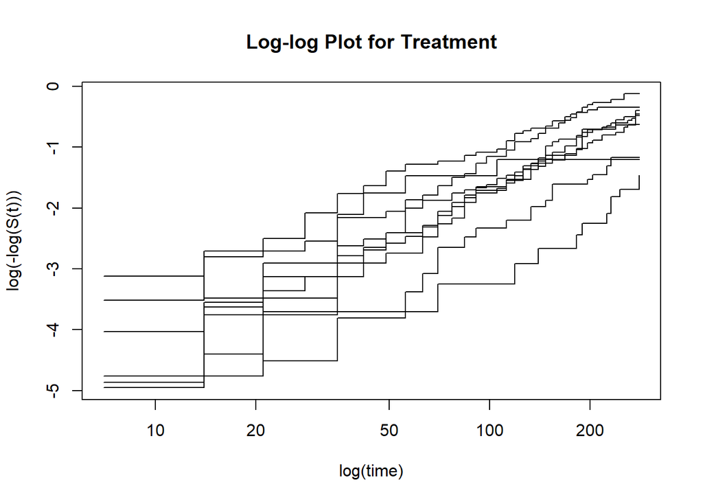

```r
ll.drm <- survfit(Surv(time, status) ~ factor(DRM), data = surv_data2)


plot(ll.drm,
     fun = "cloglog",
     main = "Log-log Plot for Treatment",
     xlab = "log(time)",
     ylab = "log(-log(S(t)))")
```

In general, if the lines are parallel we pass the assumptions. This graph looks mostly parallel but we have a bit of sketchiness. Therefore, we will continue to check our assumptions by looking at Shoenfeld residuals.

### Shoefeld Residuals

```r
sch.res <- cox.zph(dealer.fit)
sch.res
```

```
##        chisq df    p
## drm     13.7  8 0.09
## GLOBAL  13.7  8 0.09
```

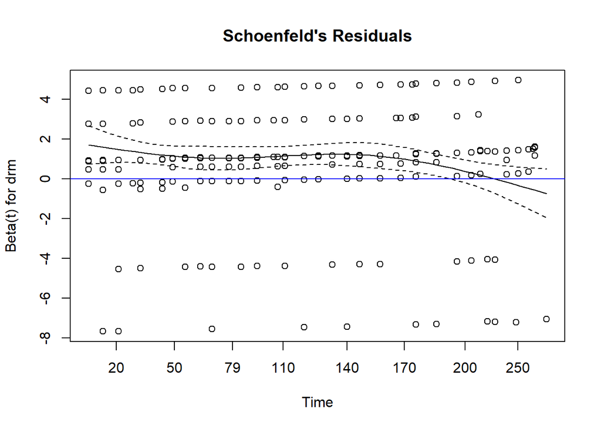

```r
plot(sch.res[1], main = "Schoenfeld's Residuals")
abline(h = 0, col = "blue")
```

## Model Building

Now lets do some model building to show what other factors besides DRM lead to a dealers cancellation. We will do this by controlling for DRM (i.e. putting it at the end of the list) and utilizing forward selection.

```r
model0 <- coxph(Surv(time, status) ~ factor(DRM), data = surv_data2)
AIC(model0)
```

```
## [1] 3936.4
```

```r
model1 <- coxph(Surv(time, status) ~ count + factor(DRM), data = surv_data2)
AIC(model1)
```

```
## [1] 3758.366
```

```r
model2 <- coxph(Surv(time, status) ~ name + factor(DRM), data = surv_data2)
AIC(model2)
```

```
## [1] 3929.639
```

```r
model3 <- coxph(Surv(time, status) ~ territory + factor(DRM), data = surv_data2)
AIC(model3)
```

```
## [1] 3964.488
```

```r
model4 <- coxph(Surv(time, status) ~ AE + factor(DRM), data = surv_data2)
AIC(model4)
```

```
## [1] 3958.869
```

```r
model5 <- coxph(Surv(time, status) ~ RSM + factor(DRM), data = surv_data2)
AIC(model5)
```

```
## [1] 3901.788
```

```r
model6 <- coxph(Surv(time, status) ~ age + factor(DRM), data = surv_data2)
AIC(model6)
```

```
## [1] 3937.249
```

It appears that count and DRM are a compatible pairing (model1). They have the lowest AIC which means that count is another effective covariate for determining cancellations. Remember that count is the amount of vehicles that a dealer looked up while using the product for the time period.

### Analysis of Model

```r
summary(model1)
```

```
## Call:
## coxph(formula = Surv(time, status) ~ count + factor(DRM), data = surv_data2)
##
##   n= 911, number of events= 311
##
##                                     coef  exp(coef)   se(coef)      z Pr(>|z|)
## count                         -0.0014473  0.9985537  0.0001649 -8.775  < 2e-16
## factor(DRM)Fernando Fernandez  0.1101967  1.1164977  0.2094475  0.526  0.59880
## factor(DRM)Jim Tourigny       -0.1755482  0.8389969  0.2113474 -0.831  0.40619
## factor(DRM)Kathryn Lamphere   -0.3131938  0.7311082  0.2169089 -1.444  0.14877
## factor(DRM)No DRM             -0.3070633  0.7356040  0.4328867 -0.709  0.47811
## factor(DRM)Robert Krajecki     0.3451714  1.4122320  0.1992378  1.732  0.08319
## factor(DRM)Sergio Suun        -0.1781272  0.8368360  0.2003465 -0.889  0.37395
## factor(DRM)Taki Caranicolas   -0.7555559  0.4697494  0.3130293 -2.414  0.01579
## factor(DRM)Will Smithies      -0.8408172  0.4313579  0.2609059 -3.223  0.00127
##
## count                         ***
## factor(DRM)Fernando Fernandez
## factor(DRM)Jim Tourigny
## factor(DRM)Kathryn Lamphere
## factor(DRM)No DRM
## factor(DRM)Robert Krajecki    .
## factor(DRM)Sergio Suun
## factor(DRM)Taki Caranicolas   *
## factor(DRM)Will Smithies      **
## ---
## Signif. codes:  0 '***' 0.001 '**' 0.01 '*' 0.05 '.' 0.1 ' ' 1
##
##                               exp(coef) exp(-coef) lower .95 upper .95
## count                            0.9986     1.0014    0.9982    0.9989
## factor(DRM)Fernando Fernandez    1.1165     0.8957    0.7406    1.6832
## factor(DRM)Jim Tourigny          0.8390     1.1919    0.5544    1.2696
## factor(DRM)Kathryn Lamphere      0.7311     1.3678    0.4779    1.1184
## factor(DRM)No DRM                0.7356     1.3594    0.3149    1.7184
## factor(DRM)Robert Krajecki       1.4122     0.7081    0.9557    2.0869
## factor(DRM)Sergio Suun           0.8368     1.1950    0.5651    1.2393
## factor(DRM)Taki Caranicolas      0.4697     2.1288    0.2543    0.8676
## factor(DRM)Will Smithies         0.4314     2.3183    0.2587    0.7193
##
## Concordance= 0.795  (se = 0.012 )
## Likelihood ratio test= 226.2  on 9 df,   p=<2e-16
## Wald test            = 110.5  on 9 df,   p=<2e-16
## Score (logrank) test = 55.16  on 9 df,   p=1e-08
```

From this summary report it is apparent that count may be an even better predictor for cancellations that the DRM. This makes inherent sense because if a dealer is using the tool less and less over time than they will be more likely to cancel.